# Pandas-Bootcamp-Part13

#### Data Formats

Input / Output

#### reading and writing

- HTML
- JSON
- Excel
- Pickle

```python
#JSON : (Javascript Object Notation) is a standardized and languaege-independent format
```

https://andybek.com/pandas-folks-json

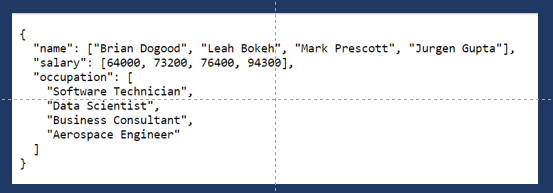

The entire JSON object is wrapped in curly braces , which reminds us of Python Dictionary or Javascript objects.

- Within those braces we have a collection of Key : Value Pairs.

The other important structures in JSON are Ordered lists. They are quite similar to Python Lists. They just contain sequence of values separated by commas.

How to read JSON objects into Python. Its not much different from reading CSVs.

```python
import pandas as pd
import numpy as np
```

```python
pd.read_json('folks.json')
```

|  | name | salary | occupation |
| --- | --- | --- | --- |
| 0 | Brian Dogood | 64000 | Software Technician |
| 1 | Leah Bokeh | 73200 | Data Scientist |
| 2 | Mark Prescott | 76400 | Business Consultant |
| 3 | Jurgen Gupta | 94300 | Aerospace Engineer |

- Each of the Keys in JSON , now represent a column in our Dataframe
- Its important to note that , at this point , the format of the data we read in no longer is important. Because , now we are working with Pandas Dataframe and it doesn't matter how we got here.

```python
folks = pd.read_json('folks.json')
```

```python
folks.head(2)
```

|  | name | salary | occupation |
| --- | --- | --- | --- |
| 0 | Brian Dogood | 64000 | Software Technician |
| 1 | Leah Bokeh | 73200 | Data Scientist |

### Reading HTML

```python
#Hypertext Markup language
```

#### HTML is standard Markup language for webpages

- If we rightclick on the Browser and inspect
- we can vuew the HTML of the webpage
- A lot of information on the web is present in the form of HTML tables that we might be interested in

#### Lets say that we want to put together a DataFrame of European Countries and their Populations

- first step is to Goole , may be the information is already there
- So we start with wikipedia : "European countries population wiki"
- So , we get a Wikipedia Article containing a Table

https://en.wikipedia.org/wiki/List_of_European_countries_by_population

- How do we read this into Pandas

Pandas has the abikity to read Data from HTML tables directly from a Webpage:

- Copy the URL
- Assign it to a variable

```python
data_url = 'https://en.wikipedia.org/wiki/List_of_European_countries_by_population'
```

```python
#We pass the data_url to this
countries = pd.read_html(data_url)
```

```python
#Lets see what we got back
type(countries)
```

```
list
```

```python
#Checking the Length of the Python list that we got
len(countries)
```

```
2
```

Meaning , there are actually two tables present on the web page

[figure not shown]

```python
countries[0]
```

|  | Country.mw-parser-output .nobold{font-weight:normal}(or territory) | UN estimate(2021)[5][6] | National statistic Estimate | National statistic Date | Source |
| --- | --- | --- | --- | --- | --- |
| 0 | Russia * [Note 1] | 145102755 | 145557576 | 1 Jan 2022 | National annual estimate[7] |
| 1 | Turkey * | 84775404 | 84680273 | 31 Dec 2021 | National annual estimate[8] |
| 2 | Germany * | 83408554 | 84270625 | 30 Sep 2022 | National quarterly estimate[9] |
| 3 | France * [Note 2] | 64531444 | 68038000 | 1 Dec 2022 | National monthly estimate[10] |
| 4 | United Kingdom * [Note 3] | 67281039 | 67026292 | 30 Jun 2021 | National annual estimate[11] |
| 5 | Italy * | 59240329 | 58853482 | 1 Aug 2022 | National monthly estimate[12] |
| 6 | Spain * | 47486935 | 47615034 | 1 Jul 2022 | National estimate[13] |
| 7 | Ukraine * [Note 4] | 43531422 | 41130432 | 1 Feb 2022 | National monthly estimate[14] |
| 8 | Poland * | 38307726 | 38014000 | 30 Apr 2022 | National monthly estimate[15] |
| 9 | Romania * | 19328560 | 19053815 | 1 Jan 2022 | 2022 Census results[16] |
| 10 | Kazakhstan * | 19196465 | 19691900 | 1 Oct 2022 | National monthly estimate[17] |
| 11 | Netherlands * | 17501696 | 17798615 | 31 Oct 2022 | National monthly estimate[18] |
| 12 | Belgium * | 11611419 | 11584008 | 1 Jan 2022 | National estimate[19] |
| 13 | Greece * | 10445365 | 10678632 | 1 Jan 2021 | National estimate[20] |
| 14 | Czech Republic * | 10510751 | 10525739 | 30 Jun 2022 | National quarterly estimate[21] |
| 15 | Sweden * | 10467097 | 10520558 | 30 Nov 2022 | National monthly estimate[22] |
| 16 | Portugal * | 10290103 | 10361800 | 16 Dec 2021 | National annual estimate[23] |
| 17 | Azerbaijan * | 10312992 | 10164464 | 1 Mar 2022 | National estimate[24] |
| 18 | Hungary * | 9709786 | 9689010 | 1 Jan 2022 | National annual estimate[25] |
| 19 | Belarus * | 9578167 | 9255500 | 1 Jan 2022 | National quarterly estimate[26] |
| 20 | Austria * | 8922082 | 9090868 | 1 Oct 2022 | Quarterly provisional figure[27] |
| 21 | Switzerland * | 8691406 | 8789726 | 30 Sep 2022 | National provisional figure[28] |
| 22 | Bulgaria * | 6885868 | 6838937 | 31 Dec 2021 | National estimate[29] |
| 23 | Serbia * [Note 5] | 7296769 | 6797105 | 1 Jan 2022 | National annual estimate[30] |
| 24 | Denmark * | 5854240 | 5883562 | 1 Apr 2022 | National quarterly estimate[31] |
| 25 | Finland * | 5535992 | 5559198 | 30 Sep 2022 | National monthly estimate[32] |
| 26 | Norway * | 5403021 | 5455582 | 30 Jun 2022 | National quarterly estimate[33] |
| 27 | Slovakia * | 5447622 | 5434712 | 31 Dec 2021 | National estimate[34] |
| 28 | Ireland * | 4986526 | 5123536 | 1 Jan 2022 | National estimate[35] |
| 29 | Croatia * | 4060135 | 3879074 | 31 Dec 2021 | National estimate[36] |
| 30 | Georgia * [Note 6] | 3757980 | 3688600 | 1 Jan 2022 | National annual estimate[37] |
| 31 | Bosnia and Herzegovina * | 3270943 | 3475000 | 15 Jun 2020 | National estimate[38] |
| 32 | Armenia * | 2790974 | 2961600 | 1 Jan 2022 | National annual estimate[39] |
| 33 | Lithuania * | 2786651 | 2838389 | 1 Oct 2022 | National monthly estimate[40] |
| 34 | Albania * | 2854710 | 2793592 | 1 Jan 2022 | National annual estimate[41] |
| 35 | Moldova * | 3061506 | 2597100 | 1 Jan 2021 | National estimate[42] |
| 36 | Slovenia * | 2119410 | 2107180 | 1 Jan 2022 | National estimate[43] |
| 37 | North Macedonia * | 2103330 | 1836713 | 31 Dec 2021 | National estimate[44] |
| 38 | Latvia * | 1873919 | 1886300 | 1 May 2022 | National estimate[45] |
| 39 | Kosovo * [Note 7] | 1662009 | 1773971 | 31 Dec 2021 | National annual estimate[46] |
| 40 | Estonia * | 1328701 | 1331796 | 1 Jan 2022 | National annual estimate[47] |
| 41 | Cyprus * | 1244188 | 918100 | 31 Oct 2021 | National annual estimate[48] |
| 42 | Luxembourg * | 639321 | 645397 | 1 Jan 2022 | National annual estimate[49] |
| 43 | Montenegro * | 627859 | 617683 | 1 Jan 2022 | National estimate[50] |
| 44 | Malta * | 526748 | 520971 | 31 Dec 2021 | National annual estimate[51] |
| 45 | Iceland * | 370335 | 385230 | 30 Sep 2022 | National quarterly estimate[52] |
| 46 | Jersey * (UK) | 109618 | 103267 | 21 Mar 2021 | National estimate[53] |
| 47 | Isle of Man * (UK) | 84263 | 84069 | 24 Apr 2021 | 2021 census result[54] |
| 48 | Andorra * | 79034 | 80120 | 1 May 2022 | National estimate[55] |
| 49 | Guernsey * (UK) | 63065 | 63155 | 31 Mar 2020 | National estimate[56] |
| 50 | Faroe Islands * (Denmark) | 52889 | 54081 | 1 Sep 2022 | National monthly estimate[57] |
| 51 | Liechtenstein * | 39039 | 39315 | 31 Dec 2021 | National semi-annual estimate[58] |
| 52 | Monaco * | 36686 | 39150 | 31 Dec 2021 | National annual estimate[59] |
| 53 | Gibraltar * (UK) | 32669 | 34003 | 26 Jun 2022 | National estimate[60] |
| 54 | San Marino * | 33745 | 33785 | 30 Sep 2022 | National monthly estimate[61] |
| 55 | Åland (Finland) | 0 | 30344 | 31 Dec 2021 | National estimate[62] |
| 56 | Vatican City * | 0 | 799 | 3 Jul 2019 | National estimate[63] |

```python
countries[0].columns
```

```
MultiIndex([('Country.mw-parser-output .nobold{font-weight:normal}(or territory)', ...),
            (                                           'UN estimate(2021)[5][6]', ...),
            (                                                'National statistic', ...),
            (                                                'National statistic', ...),
            (                                                            'Source', ...)],
           )
```

### Lets fix the Header

```python
#We see duplicate Header
#We want the Position 1 header
```

```python
countries = pd.read_html(data_url , header = 0)
```

```python
countries[0].head(2)
```

|  | Country.mw-parser-output .nobold{font-weight:normal}(or territory) | UN estimate(2021)[5][6] | National statistic | National statistic.1 | Source |
| --- | --- | --- | --- | --- | --- |
| 0 | Country.mw-parser-output .nobold{font-weight:n... | UN estimate(2021)[5][6] | Estimate | Date | Source |
| 1 | Russia * [Note 1] | 145102755 | 145557576 | 1 Jan 2022 | National annual estimate[7] |

```python
#Still not proper
#We change the header to position : 1
countries = pd.read_html(data_url , header = 1)
```

```python
countries[0].head(3)
```

|  | Country.mw-parser-output .nobold{font-weight:normal}(or territory) | UN estimate(2021)[5][6] | Estimate | Date | Source |
| --- | --- | --- | --- | --- | --- |
| 0 | Russia * [Note 1] | 145102755 | 145557576 | 1 Jan 2022 | National annual estimate[7] |
| 1 | Turkey * | 84775404 | 84680273 | 31 Dec 2021 | National annual estimate[8] |
| 2 | Germany * | 83408554 | 84270625 | 30 Sep 2022 | National quarterly estimate[9] |

we will remove all the columns that we do not need

```python
#We use Label based indexing
```

```python
countries[0].columns = ['Country' , 'UN_Estimate' , 'Estimate' , 'Date' , 'Source']
```

```python
countries[0].head(2)
```

|  | Country | UN_Estimate | Estimate | Date | Source |
| --- | --- | --- | --- | --- | --- |
| 0 | Russia * [Note 1] | 145102755 | 145557576 | 1 Jan 2022 | National annual estimate[7] |
| 1 | Turkey * | 84775404 | 84680273 | 31 Dec 2021 | National annual estimate[8] |

```python
countries[0].loc[: , ['Country' , 'Estimate']]
```

|  | Country | Estimate |
| --- | --- | --- |
| 0 | Russia * [Note 1] | 145557576 |
| 1 | Turkey * | 84680273 |
| 2 | Germany * | 84270625 |
| 3 | France * [Note 2] | 68038000 |
| 4 | United Kingdom * [Note 3] | 67026292 |
| 5 | Italy * | 58853482 |
| 6 | Spain * | 47615034 |
| 7 | Ukraine * [Note 4] | 41130432 |
| 8 | Poland * | 38014000 |
| 9 | Romania * | 19053815 |
| 10 | Kazakhstan * | 19691900 |
| 11 | Netherlands * | 17798615 |
| 12 | Belgium * | 11584008 |
| 13 | Greece * | 10678632 |
| 14 | Czech Republic * | 10525739 |
| 15 | Sweden * | 10520558 |
| 16 | Portugal * | 10361800 |
| 17 | Azerbaijan * | 10164464 |
| 18 | Hungary * | 9689010 |
| 19 | Belarus * | 9255500 |
| 20 | Austria * | 9090868 |
| 21 | Switzerland * | 8789726 |
| 22 | Bulgaria * | 6838937 |
| 23 | Serbia * [Note 5] | 6797105 |
| 24 | Denmark * | 5883562 |
| 25 | Finland * | 5559198 |
| 26 | Norway * | 5455582 |
| 27 | Slovakia * | 5434712 |
| 28 | Ireland * | 5123536 |
| 29 | Croatia * | 3879074 |
| 30 | Georgia * [Note 6] | 3688600 |
| 31 | Bosnia and Herzegovina * | 3475000 |
| 32 | Armenia * | 2961600 |
| 33 | Lithuania * | 2838389 |
| 34 | Albania * | 2793592 |
| 35 | Moldova * | 2597100 |
| 36 | Slovenia * | 2107180 |
| 37 | North Macedonia * | 1836713 |
| 38 | Latvia * | 1886300 |
| 39 | Kosovo * [Note 7] | 1773971 |
| 40 | Estonia * | 1331796 |
| 41 | Cyprus * | 918100 |
| 42 | Luxembourg * | 645397 |
| 43 | Montenegro * | 617683 |
| 44 | Malta * | 520971 |
| 45 | Iceland * | 385230 |
| 46 | Jersey * (UK) | 103267 |
| 47 | Isle of Man * (UK) | 84069 |
| 48 | Andorra * | 80120 |
| 49 | Guernsey * (UK) | 63155 |
| 50 | Faroe Islands * (Denmark) | 54081 |
| 51 | Liechtenstein * | 39315 |
| 52 | Monaco * | 39150 |
| 53 | Gibraltar * (UK) | 34003 |
| 54 | San Marino * | 33785 |
| 55 | Åland (Finland) | 30344 |
| 56 | Vatican City * | 799 |

```python
countries = countries[0].loc[: , ['Country' , 'Estimate']]
```

```python
countries.head(2)
```

|  | Country | Estimate |
| --- | --- | --- |
| 0 | Russia * [Note 1] | 145557576 |
| 1 | Turkey * | 84680273 |

```python
#Data Cleaning
#Removing text like [Note 1].... which is pointing to a different link
```

```python
countries.head(2)
```

|  | Country | Estimate |
| --- | --- | --- |
| 0 | Russia * [Note 1] | 145557576 |
| 1 | Turkey * | 84680273 |

```python
#Using Regex
#The Pattern is : [Note x]
#x represents a digit
#We escape the square brackets because it has a special meaning in regex
#Square brackets represent Character sets
#We escape both the square brackets with backslash
#We want to replace anything that matches this pattern with nothing
```

```python
countries.replace(r'\[Note \d+\]', '' , regex = True , inplace = True)
```

```python
countries.head(10)
```

|  | Country | Estimate |
| --- | --- | --- |
| 0 | Russia * | 145557576 |
| 1 | Turkey * | 84680273 |
| 2 | Germany * | 84270625 |
| 3 | France * | 68038000 |
| 4 | United Kingdom * | 67026292 |
| 5 | Italy * | 58853482 |
| 6 | Spain * | 47615034 |
| 7 | Ukraine * | 41130432 |
| 8 | Poland * | 38014000 |
| 9 | Romania * | 19053815 |

```python
countries['Country'].str.strip(' *')
```

```
0                       Russia
1                       Turkey
2                      Germany
3                       France
4               United Kingdom
5                        Italy
6                        Spain
7                      Ukraine
8                       Poland
9                      Romania
10                  Kazakhstan
11                 Netherlands
12                     Belgium
13                      Greece
14              Czech Republic
```

[output cut: 43 more lines]

```python
countries['Country'] = countries['Country'].str.strip(' *')
```

```python
countries.head(3)
```

|  | Country | Estimate |
| --- | --- | --- |
| 0 | Russia | 145557576 |
| 1 | Turkey | 84680273 |
| 2 | Germany | 84270625 |

#### Creating BAR chart of the largest 10 European Countries by Population to see how they compare

```python
countries =countries.squeeze()
```

```python
type(countries)
```

```
pandas.core.frame.DataFrame
```

```python
countries.head(2)
```

|  | Country | Estimate |
| --- | --- | --- |
| 0 | Russia | 145557576 |
| 1 | Turkey | 84680273 |

```python
countries = countries.set_index('Country')
```

```python
countries.head(3)
```

| Country | Estimate |
| --- | --- |
| Russia | 145557576 |
| Turkey | 84680273 |
| Germany | 84270625 |

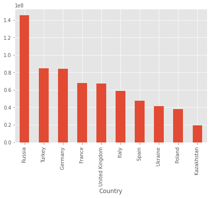

```python
from matplotlib import pyplot as plt
plt.style.use('ggplot')
countries.Estimate.nlargest(10).plot(kind = 'bar' , y= 'Estimate' , figsize = (7,5));
```

### Reading EXCEL

Popular Excel Formats:

```
- .xls -> binary Format
- .xlsx -> xml-based , available in newer versions
```

Excel Spreadsheet consists of a Grid of cells arranged in numbered Rows and lettered Columns

https://andybek.com/folks.xlsx

```python
folks = pd.read_excel('folks.xlsx')
```

```python
folks.head()
```

|  | name | salary | occupation |
| --- | --- | --- | --- |
| 0 | Brian Dogood | 64000 | Software Technician |
| 1 | Leah Bokeh | 73200 | Data Scientist |
| 2 | Mark Prescott | 76400 | Business Consultant |
| 3 | Jurgen Gupta | 94300 | Aerospace Engineer |

```python
#There were two worksheets in the Excel and we read the first one : "folks"
folks = pd.read_excel('folks.xlsx' , sheet_name = 'hobbies')
```

```python
folks.head(2)
```

|  | name | hobby |
| --- | --- | --- |
| 0 | Brian Dogood | Fishing |
| 1 | Leah Bokeh | Skateboarding |

'xlrd' is being used to read in our traditional xlsx files

PANDAS optional dependencies for reading Data https://pandas.pydata.org/docs/getting_started/install.html

pip is a popular Package management system in Python

### Creating Output: The to_*Family of methods

```python
#I/O --> Input/Output
```

so far we have only explored the Input Side of I/O

- We are also interested in exporting our manipulated data back

```python
folks
```

|  | name | hobby |
| --- | --- | --- |
| 0 | Brian Dogood | Fishing |
| 1 | Leah Bokeh | Skateboarding |
| 2 | Mark Prescott | Value Investing |
| 3 | Jurgen Gupta | Drawing |

```python
hobbies = folks.copy()
```

```python
hobbies.head()
```

|  | name | hobby |
| --- | --- | --- |
| 0 | Brian Dogood | Fishing |
| 1 | Leah Bokeh | Skateboarding |
| 2 | Mark Prescott | Value Investing |
| 3 | Jurgen Gupta | Drawing |

```python
#Insert a new person with a New hobby and save it as csv
#We are creating a Label '4'
hobbies.loc[4] = ['Zoltan Zachary' , 'Archery']
```

```python
hobbies.head()
```

|  | name | hobby |
| --- | --- | --- |
| 0 | Brian Dogood | Fishing |
| 1 | Leah Bokeh | Skateboarding |
| 2 | Mark Prescott | Value Investing |
| 3 | Jurgen Gupta | Drawing |
| 4 | Zoltan Zachary | Archery |

```python
#We create Age column
#We wanrt Numpy to generate 5 highly precise Ages for this
#We want Age to be between 22 and 54 and we want  5 Ages
np.random.uniform(22 , 54 , 5)
```

```
array([38.83569633, 41.11742634, 33.9359731 , 29.03244564, 35.6724773 ])
```

For every "read" method in Pandas there is a corresponding "write" method

```python
#read_csv, read_excel , read_html....
#to_csv , to_excel , to_html....
```

```python
#This below method creates the csv in the Notebook
#hobbies.to_csv()

#But with this method , a proper csv file is created
#hobbies.to_csv('hobbies.csv' , index = False)
```

```python
#We can view the File if its created by entering the list command to see the content of the directory
import os
from os import listdir
os. listdir()
```

```
['.ipynb_checkpoints',
 '2017BostonMarathonTop1000.csv',
 'BrentOilPrices.csv',
 'CardioGoodFitness.csv',
 'drinks.csv',
 'eng.csv',
 'folks.json',
 'folks.xlsx',
 'games_sales.csv',
 'ivies.csv',
 'liberal_arts.csv',
 'mid_career_salaries.csv',
 'nba2019.csv',
 'new_states.json',
 'Nutrition.csv',
 'Pandas-Bootcamp-Part12.ipynb',
 'Pandas-Bootcamp-Part13.ipynb',
 'party.csv',
 'regions.csv',
 'scores.csv',
 'soccer.csv',
 'state.csv',
 'states.json',
 'tech_giants.csv']
```

#### Producing JSON

```python
#hobbies.to_json('hobbies.json')
```

#### Producing HTML

```python
#hobbies.to_html('hobbies.html')
```

### Pickle - Python Object Serialization

Serialization is the process of converting an object into a stream of bytes, to be stored or transmitted over a network pickle : the Python standard library module responsible for serialization

- Here we are working with a Python Dictionary that contains information on a stock

```python
googl = {'ticker' : 'GOOGL' , 'shares':10 , 'book_cost' : 1540.23}
```

```python
import pickle
```

```python
#We will open the file with the "write" permissions --> "write binary"
```

```python
pickle_output = open('my_stock' , 'wb')
```

```python
#Lets go ahead and dump our "googl" object into that File
```

```python
pickle.dump(googl , pickle_output)
```

```python
#We indicate to Python that we are done writing into that File
pickle_output.close()
```

```python
os.listdir()
```

```
['.ipynb_checkpoints',
 '2017BostonMarathonTop1000.csv',
 'BrentOilPrices.csv',
 'CardioGoodFitness.csv',
 'drinks.csv',
 'eng.csv',
 'folks.json',
 'folks.xlsx',
 'games_sales.csv',
 'ivies.csv',
 'liberal_arts.csv',
 'mid_career_salaries.csv',
 'my_stock',
 'nba2019.csv',
 'new_states.json',
 'Nutrition.csv',
 'Pandas-Bootcamp-Part12.ipynb',
 'Pandas-Bootcamp-Part13.ipynb',
 'party.csv',
 'regions.csv',
 'scores.csv',
 'soccer.csv',
 'state.csv',
 'states.json',
 'tech_giants.csv']
```

```python
type(pickle_output)
```

```
_io.BufferedWriter
```

- Note , this file "my_stock" is not really readable
- To bring it back to the Python object , we will use the "open" function
- But this time with "read binary" instead of "write binary"

```python
pickle_input = open('my_stock' , 'rb')
```

- We use the "load" method on the "pickle" module to load the stream of bytes back into a Python Dictionary

```python
stock_dict = pickle.load(pickle_input)
```

```python
stock_dict
```

```
{'ticker': 'GOOGL', 'shares': 10, 'book_cost': 1540.23}
```

### What we did?

This is how we went from Python Dictionary to bytes and back to Python Dictionary

Serialization is also known as "marshalling" or "flattening" in other Programming Languages

```python
!pip install hexdump
```

```python
from hexdump import hexdump
```

```python
#print( hexdump(data))
```

In Python the Pickle Module is used to Serialize and De-Serialize the Python Objects.

- Pickeling is not Compression of data ,its merely transformation from one representation to another

### Reading and Writing Pickles in Pandas

https://andybek.com/portfolio

Python Pickle is a kind of Data Format in Python

This Portfolio File is a Pickled DataFrame

```python
#Reading Pickle File
pd.read_pickle('portfolio')
```

|  | ticker | shares | book_cost |
| --- | --- | --- | --- |
| 0 | AAPL | 150 | 123.23 |
| 1 | GOOGL | 10 | 1100.00 |
| 2 | AMGN | 230 | 227.23 |
| 3 | VET | 200 | 14.24 |
| 4 | TSLA | 100 | 260.00 |
| 5 | DX | 40 | 20.01 |

```python
folio = pd.read_pickle('portfolio')
```

- We could now create a pickle out of this DataFrame by using the to_pickle method and pass in a File Name

```python
folio.to_pickle('folio')
```

```python
#We see that 'folio' has been created
os.listdir()
```

```
['.ipynb_checkpoints',
 '2017BostonMarathonTop1000.csv',
 'BrentOilPrices.csv',
 'CardioGoodFitness.csv',
 'drinks.csv',
 'eng.csv',
 'folio',
 'folks.json',
 'folks.xlsx',
 'games_sales.csv',
 'ivies.csv',
 'liberal_arts.csv',
 'mid_career_salaries.csv',
 'my_stock',
 'nba2019.csv',
 'new_states.json',
 'Nutrition.csv',
 'Pandas-Bootcamp-Part12.ipynb',
 'Pandas-Bootcamp-Part13.ipynb',
 'party.csv',
 'portfolio',
 'regions.csv',
 'scores.csv',
 'soccer.csv',
 'state.csv',
 'states.json',
 'tech_giants.csv']
```

This is how we read and write Pickles in Pandas

```python
pd.read_pickle('folio')
```

|  | ticker | shares | book_cost |
| --- | --- | --- | --- |
| 0 | AAPL | 150 | 123.23 |
| 1 | GOOGL | 10 | 1100.00 |
| 2 | AMGN | 230 | 227.23 |
| 3 | VET | 200 | 14.24 |
| 4 | TSLA | 100 | 260.00 |
| 5 | DX | 40 | 20.01 |

Generally speaking , you should not load pickles that you receive from untrusted sources

https://www.udemy.com/course/the-ultimate-pandas-bootcamp-advanced-python-data-analysis/learn/lecture/19555118#overview

https://www.udemy.com/course/the-ultimate-pandas-bootcamp-advanced-python-data-analysis/learn/lecture/19555128#overview

#### For Many other Formats :

```
https://pandas.pydata.org/docs/user_guide/io.html
```

Note : SQL : Pandas has the ability to read directly from SQL databases

### Skill Challenge

1. If you head over to https://andybek.com/traders you'll find the Page listing trader positions and some attributes. Using Pandas read this table directly into a Pandas DataFrame. Assign the dataframe to the variable positions.

```python
import pandas as pd
import numpy as np
```

```python
!python --version
```

```
Python 3.8.3
```

```python
pd.read_html('https://www.andybek.com/traders/')
```

[output not shown]

[output cut: 90 more lines]

[output not shown]

#### <urlopen error [SSL: CERTIFICATE_VERIFY_FAILED] certificate verify failed: certificate has expired (_ssl.c:1108)>

```python
import ssl
ssl._create_default_https_context = ssl._create_unverified_context
```

```python
pd.read_html('https://www.andybek.com/traders/')
```

```
[  TraderID    Instrument   Amount Trader Location
 0   MCBIRN     02079K107   150000              EU
 1    WISEA     1350Z74U5  6400000              EU
 2    IACOP  GB00B3KJDQ49  2430000              US]
```

We have actually got a list here , because the data on the HTML contains a single item

- To access the table , we simply index [0]

```python
type(pd.read_html('https://www.andybek.com/traders/'))
```

```
list
```

```python
pd.read_html('https://www.andybek.com/traders/')[0]
```

|  | TraderID | Instrument | Amount | Trader Location |
| --- | --- | --- | --- | --- |
| 0 | MCBIRN | 02079K107 | 150000 | EU |
| 1 | WISEA | 1350Z74U5 | 6400000 | EU |
| 2 | IACOP | GB00B3KJDQ49 | 2430000 | US |

```python
positions = pd.read_html('https://www.andybek.com/traders/')[0]
```

1. The Positions we imported in the step above contain trader aliases. Over at https://andybek.com/pandas-traders-names . We have more information on the name and Seniority of each trader. What is the Data format served at this URL ? Read it into Pandas Dataframe called traders.

This is how the data is present on the URL:

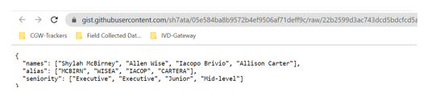

We can determine from the Structure that , it is a JSON. Java Sript Object Notation. We have a Series of Key : Value pairs.

```python
traders = pd.read_json('https://andybek.com/pandas-traders-names')
```

```python
traders
```

|  | names | alias | seniority |
| --- | --- | --- | --- |
| 0 | Shylah McBirney | MCBIRN | Executive |
| 1 | Allen Wise | WISEA | Executive |
| 2 | Iacopo Brivio | IACOP | Junior |
| 3 | Allison Carter | CARTERA | Mid-level |

1. Combine the two dataframes from the previous steps into a Dataframe that combines positions with the "full name" and "Sseniority" of each trader.

```python
positions
```

|  | TraderID | Instrument | Amount | Trader Location |
| --- | --- | --- | --- | --- |
| 0 | MCBIRN | 02079K107 | 150000 | EU |
| 1 | WISEA | 1350Z74U5 | 6400000 | EU |
| 2 | IACOP | GB00B3KJDQ49 | 2430000 | US |

```python
traders
```

|  | names | alias | seniority |
| --- | --- | --- | --- |
| 0 | Shylah McBirney | MCBIRN | Executive |
| 1 | Allen Wise | WISEA | Executive |
| 2 | Iacopo Brivio | IACOP | Junior |
| 3 | Allison Carter | CARTERA | Mid-level |

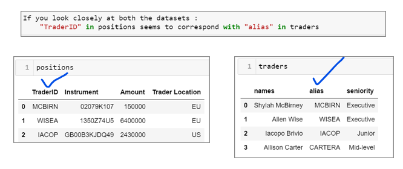

By Default : its an "inner join" : Only common trader IDs get into the resulting merged Dataframe

```python
positions.merge(traders , left_on = 'TraderID' , right_on = 'alias')
```

|  | TraderID | Instrument | Amount | Trader Location | names | alias | seniority |
| --- | --- | --- | --- | --- | --- | --- | --- |
| 0 | MCBIRN | 02079K107 | 150000 | EU | Shylah McBirney | MCBIRN | Executive |
| 1 | WISEA | 1350Z74U5 | 6400000 | EU | Allen Wise | WISEA | Executive |
| 2 | IACOP | GB00B3KJDQ49 | 2430000 | US | Iacopo Brivio | IACOP | Junior |

```python
#We can drop "alias" column , because it is repeated
#We need to specify the Column Axis if we use "drop()" otherwise we will get a "Key Error"
#KeyError: "['alias'] not found in axis"
#If we use "drop( columns = 'alias')"" then no need of specifying the "axis"
```

```python
positions.merge(traders , left_on = 'TraderID' , right_on = 'alias').drop('alias', axis = 1)
```

|  | TraderID | Instrument | Amount | Trader Location | names | seniority |
| --- | --- | --- | --- | --- | --- | --- |
| 0 | MCBIRN | 02079K107 | 150000 | EU | Shylah McBirney | Executive |
| 1 | WISEA | 1350Z74U5 | 6400000 | EU | Allen Wise | Executive |
| 2 | IACOP | GB00B3KJDQ49 | 2430000 | US | Iacopo Brivio | Junior |

```python
positions.merge(traders , left_on = 'TraderID' , right_on = 'alias').drop( columns = 'alias')
```

|  | TraderID | Instrument | Amount | Trader Location | names | seniority |
| --- | --- | --- | --- | --- | --- | --- |
| 0 | MCBIRN | 02079K107 | 150000 | EU | Shylah McBirney | Executive |
| 1 | WISEA | 1350Z74U5 | 6400000 | EU | Allen Wise | Executive |
| 2 | IACOP | GB00B3KJDQ49 | 2430000 | US | Iacopo Brivio | Junior |

```python
#Dropping Row at specific Index
positions.merge(traders , left_on = 'TraderID' , right_on = 'alias').drop(0, axis = 0)
```

|  | TraderID | Instrument | Amount | Trader Location | names | alias | seniority |
| --- | --- | --- | --- | --- | --- | --- | --- |
| 1 | WISEA | 1350Z74U5 | 6400000 | EU | Allen Wise | WISEA | Executive |
| 2 | IACOP | GB00B3KJDQ49 | 2430000 | US | Iacopo Brivio | IACOP | Junior |

```python
mrgd = positions.merge(traders , left_on = 'TraderID' , right_on = 'alias').drop( columns = 'alias')
```

```python
mrgd.head()
```

|  | TraderID | Instrument | Amount | Trader Location | names | seniority |
| --- | --- | --- | --- | --- | --- | --- |
| 0 | MCBIRN | 02079K107 | 150000 | EU | Shylah McBirney | Executive |
| 1 | WISEA | 1350Z74U5 | 6400000 | EU | Allen Wise | Executive |
| 2 | IACOP | GB00B3KJDQ49 | 2430000 | US | Iacopo Brivio | Junior |

```python
mrgd.to_pickle('pickled_traders')
```

```python
import os
```

```python
os.getcwd()
```

```
'D:\\MY_JUPYTER\\Bootcamp'
```

Note : A pickled file will not show any extension

https://www.udemy.com/course/the-ultimate-pandas-bootcamp-advanced-python-data-analysis/learn/lecture/19711858#overview